# Oregon DEQ Water Quality Status and Trends report for the Cow Creek-Nehalem River Strategic Implementation Area and Coordinated Streamside Management

January 2018

# 1 - Methods

## 1.1 Data Sources

Analysts retrieved data from [DEQ](http://www.oregon.gov/deq/wq/Pages/WQdata.aspx) (LASAR and ELEMENT), EPA ([Storet](https://www.epa.gov/waterdata/water-quality-data-wqx)) USGS ([NWIS](https://qwwebservices.usgs.gov/), [Water Quality Portal](https://www.waterqualitydata.us/)) databases.A summary of all organizations that provided data that was queried and evaluated for use in this report is found in the Appendix. The time period for the query was from 2000-01-01 to 2018-01-01. Parameters included in the query were temperature, total suspended solids, total phosphorus, and bacteria. The data returned were evaluated for data quality. EPA and USGS data were included unless result comments indicated problems with the data. Recent data (after June 2014) from the USGS was marked as provisional data and included in this analysis.

## 1.2 Decision Criteria

Status and long-term trends of the data were assessed for evaluating water quality in relation to water quality criterion or TMDL allocations. A decision criterion has been created for selecting stations that had greater than eight years of data and/or data to address water quality status. Monitoring data from tribal lands were not included in this analysis. Dominant land use characteristics were used as a station descriptor, not a deciding factor.

# 2 - Analysis

DEQ compared pH results from both grab and continuous sample data to the water quality criterion. The bacteria standard is based on the presence of E. coli compared to a single sample maximum and a geometric mean of five or more samples in a 90 day period. The temperature standard is based on the calculation of the seven day average of the daily maximum stream temperatures. When applicable, total suspended solids and total phosphorus were compared to the TMDL load allocation. If no allocation was present, total suspended solid and total phosphorus result values were plotted over time. Trends for E. coli, total phosphorus, and total suspended solids were assessed using Seasonal Kendall Analysis, which removes the influence of season-to-season fluctuations . The Seasonal Kendall Analysis also indicates the statistical significance and slope of the trend [Hirsch et al. 1982](https://profile.usgs.gov/myscience/upload_folder/ci2012Oct1508260828033Techniques%20of%20Trend%20Analysis%20for%20Monthly%20Water%20Quality%20Data.pdf).

For temperature trend analysis, analysts used data only from stations with eight years of continuous hourly temperature data in each month during the query period. Data were not used if observations were missing for more than one day each month or if fewer than 22 hourly measurements were recorded during the day. These criteria resulted in no more than 10% missing data across each of the temporal periods of interest. Fish use and spawning maps were used to determine the applicable temperature standards for the spawning and non-spawning time periods.

The results of this report includes graphs for stations with data that exceeded a water quality criterion more than once and/or showed a positive or negative trend. When insufficient data were available, that was noted in the graphs.

# 3 - Results

## 3.1 - Station Locations

[interactive chart not shown]

## 3.2 Land Use

Each monitoring station that fit the criteria to assess water quality status and/or trends was included in the land use analysis. The Stream-Catchment ([StreamCat](https://www.epa.gov/national-aquatic-resource-surveys/streamcat)) developed by EPA was used to summarize the cumulative upstream catchment of each station for primary landuse characteristics, based on the National Hydrography Dataset Plus Version 2 geospatial framework. NLCD layer can be viewed as an option in the interactive map.

*Summary table of watershed land use by station, only stations which have at least 8 years of yearly data (between 2000 and 2017) and/or are used to evaluate last known status. Source: 2011 NLCD*

| Station ID | Station Description | Watershed Area (km<sup>2</sup>) | %Urban | %Forest | %Ag | %Range | %Other |
| --- | --- | --- | --- | --- | --- | --- | --- |
| 23509 | Nehalem River downstream of Humbug Creek at Lower Nehalem Road | 1402 | 5 | 56 | 1 | 37 | 1 |

## 3.3 Water Quality Limited Stream Segments

Cronin Creek is listed for temperature during the spawning period only. The mainstem Nehalem River is listed for temperature year-round and DO during spawning in the Cronin Creek 6th field. The Cronin Creek Watershed in almost completely forestry. There are only a handful of residential properties in this basin mostly along the mainstem Nehalem River at the upstream section of the 6th field. DEQ has established a long-term temperature monitoring site on the Nehalem River at the downstream edge of this 6th field (LASAR ID: 29292 Nehalem River upstream of Salmonberry River; this site is not located within the SIA boundary) and has a DO site where data was collected from 2012 to 2015 (LASAR ID: 29292 Nehalem River at Salmonberry River; this site is not located within the SIA boundary).

Cow Creek does not have any water quality listings but Quartz Creek, which is part of the 6th field, is listed for Bio-criteria year-round. The mainstem Nehalem River is listed for temperature year-round and DO during spawning. The mainstem Nehalem has a fair amount of ag operations and rural residential land use in this reach and Cow Creek lower reach includes a portion of rural residential land use that includes the community of Jewell. Quartz Creek is entirely forestry land use. DEQ has another long-term temperature monitoring site and data has shown significate temperature exceedances in the Nehalem River just above Cow Creek 6th field, daily max temperature reaching 84 degrees Fahrenheit (LASAR ID: 23284 Nehalem River at Fishhawk Road Bridge; not located within the SIA boundary). DEQ has also collected DO data near Spruce Run from 2012 to 2015 (LASAR ID: 29302 Nehalem River at Spruce Run Creek).

*Summary of Oregon’s 2012 Integrated Report Assessment database and 303(d) list for parameters included in this report. Table based on the 2012 Integrated Report Listings by the EPA*

[output not shown]

*Assessment Categories: Cat 4A: Water quality limited, TMDL approved; Cat 5: Water quality limited, 303(d) list, TMDL needed*

## 3.4 Seasonal Kendall Trend Analysis

*Output for the Seasonal Kendall analysis, which was performed to assess trends on data that had at least 8 years of data between 2000 and 2017. Only stations used in this analysis are included in this table. The values in the N column represent the number of results for each analyte at each monitoring station and includes duplicate values. If no table is present, no stations have enough data (>8 years) to assess trends.*

## 3.5 Total Suspended Solids

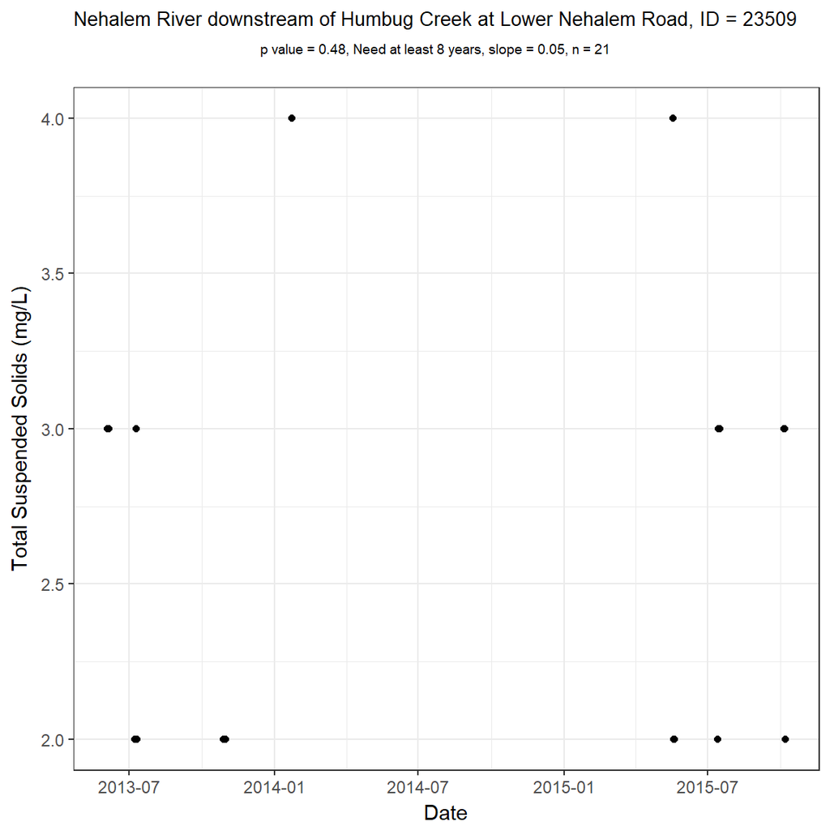

Total Suspended Solids water quality status and trends

| Station ID | Station Description | Min Date | Max Date | Obs |
| --- | --- | --- | --- | --- |
| 23509 | Nehalem River downstream of Humbug Creek at Lower Nehalem Road | 2013 | 2015 | 21 |

## 3.6 Dissolved Oxygen

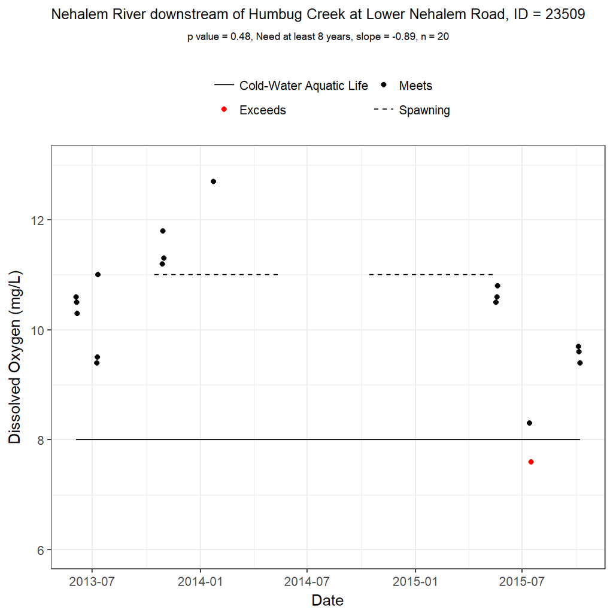

Dissolved Oxygen water quality status and trends

| Station ID | Station Description | Obs | Exceedances | Meets b/c %Sat | Min Date | Max Date | % Exceedance |
| --- | --- | --- | --- | --- | --- | --- | --- |
| 23509 | Nehalem River downstream of Humbug Creek at Lower Nehalem Road | 18 | 1 | 0 | 2013 | 2015 | 5.6 |

## 3.7 pH

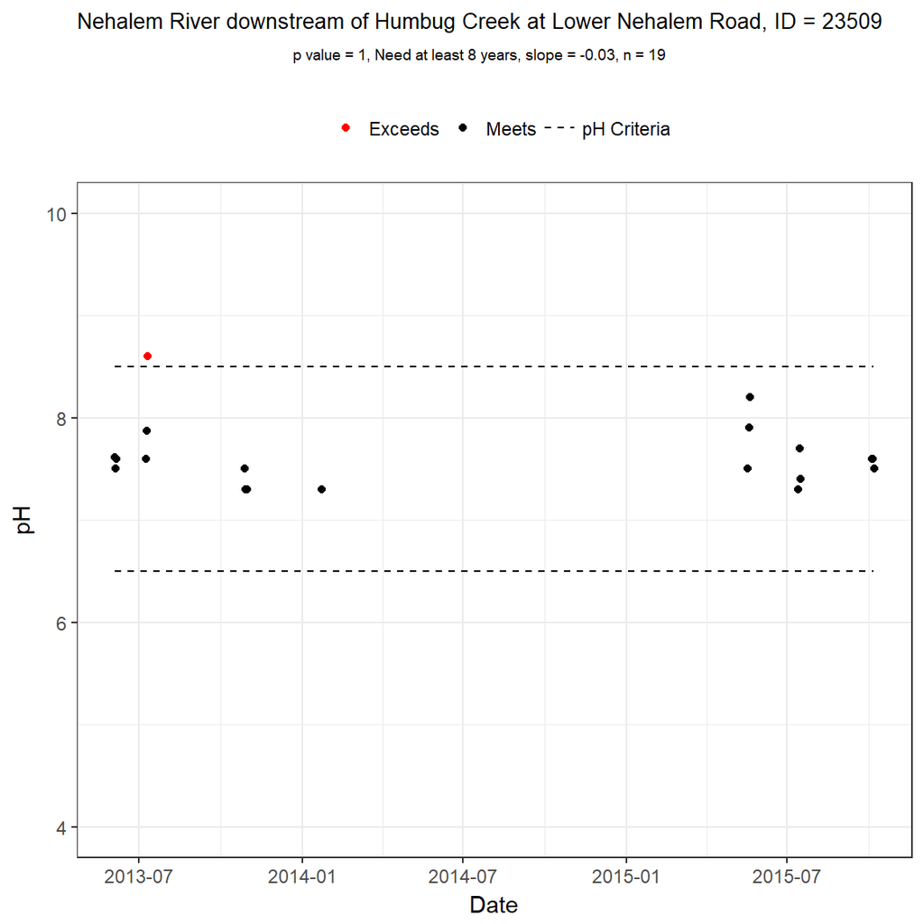

pH water quality status and trends

[output not shown]

# 4 - Appendix

Summary table of all unique organizations that were queried; note that organizations included in this table may or may not have had data sufficient for status and/or trends analysis and therefore may not be included in this report

| Organization | Observations | ‘Unique Stations’ | ‘NA obs’ | ‘Unique Comments’ |
| --- | --- | --- | --- | --- |
| TMDL - Northwest Region | 201 | 2 | 0 | 2 |
| Toxics Monitoring Program - Water | 35 | 2 | 0 | 3 |
| Tillamook Estuaries Partnership | 4 | 1 | 0 | 1 |
| EPA National Aquatic Resource Survey Data | 4 | 1 | 0 | 3 |
| EPA National Aquatic Resources Survey (NARS) | 4 | 1 | 0 | 4 |
| Toxics Monitoring Program - Sediment | 3 | 1 | 0 | 1 |

All monitoring stations that were queried and the number of results per year from 2000 to 2017

[output not shown]